# R Notebook

# Introduction

This course aims to provide students with an introduction to [data science](https://en.wikipedia.org/wiki/Data_science). Specifically, the course will introduce students to the basic data science workflow following current best practices, and address computational or algorithmic ways to think about data and learning from data. A heavy emphasis will be placed on [data visualization](https://en.wikipedia.org/wiki/Data_visualization), [exploratory data analysis](https://en.wikipedia.org/wiki/Exploratory_data_analysis), and foundational [statistical modeling](https://en.wikipedia.org/wiki/Statistical_model) and [machine learning](https://en.wikipedia.org/wiki/Machine_learning) principles.

## What is Data Science?

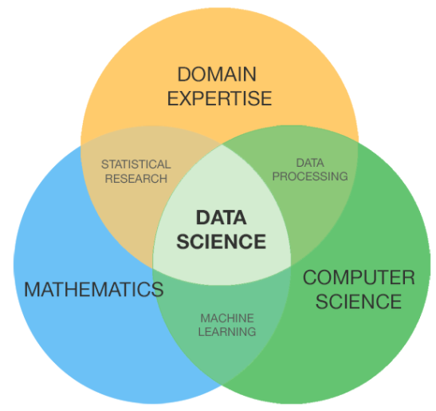

> Data Science is an emerging new field that (1) is extremely transdisciplinary - bridging between the theoretical, computational, experimental, and biosocial areas; (2) deals with enormous amounts of complex, incongruent, and dynamical data from multiple sources; and (3) aims to develop algorithms, methods, tools, and services capable of ingesting such datasets and generating semiautomated decision support systems. The latter can mine the data for patterns or motifs, predict expected outcomes, suggest clustering or labeling of retrospective or prospective observations, compute data signatures or fingerprints, extract valuable information, and offer evidence-based actionable knowledge. Data science techniques often involve manipulation (wrangling), data harmonization and aggregation, exploratory or confirmatory data analyses, [predictive analytics](https://en.wikipedia.org/wiki/Predictive_analytics), validation, and fine-tuning.

From Chapter 1 of Dinov, ID. (2018) *Data Science and Predictive Analytics: Biomedical and Health Applications using R*, see also the accompanying [website](http://socr.umich.edu/people/dinov/DSPA_Courses.html).

## The Data Science Workflow

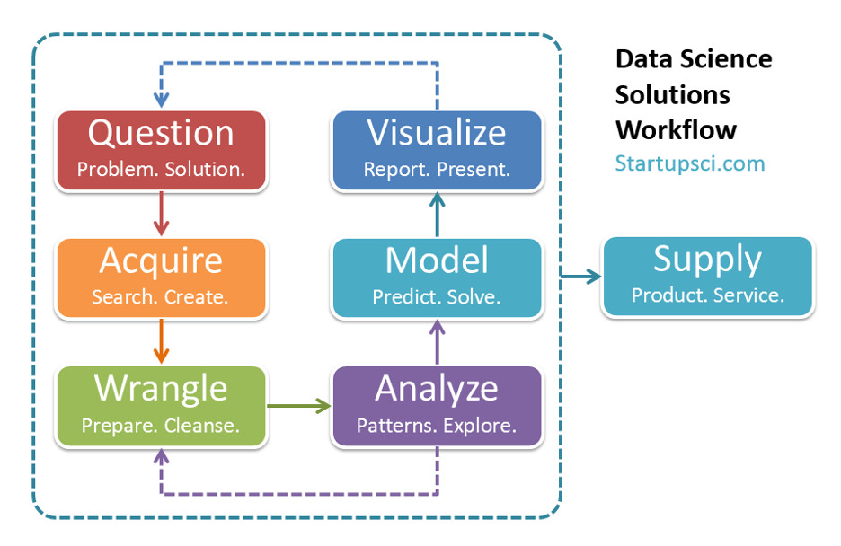

The successful implementation of the data science workflow requires the use of an appropriate technological toolset. In this course an emphasis will be placed using [R](https://www.r-project.org/), [RStudio](https://www.rstudio.com/), and [RMarkdown](https://rmarkdown.rstudio.com/) to implement the data science workflow.

[figure not shown]

A very commonly used alternative to the R-centric tools we will use is the Python-centric tollkit made up of [Python](https://www.python.org/), [Jupyter](https://jupyter.org/), and a host of Python libraries for data science. For those that are interested, the book [Pandas for Everyone](https://www.pearson.com/us/higher-education/program/Chen-Pandas-for-Everyone-Python-Data-Analysis/PGM335102.html) is a great reference that parallels much of what we will do in the course but using Python instead of R.

## The Data in Data Science

Raw data comes in many different forms, e.g. numerical measurements, text, images, videos, sounds which makes it difficult to precisely answer “what is data?”. However, in many tpical applications, the data one works with will have some definite structure or type to it and it is very useful to being to get to know about this. Let’s look at a motivating example from [gapminder](https://www.gapminder.org/).

## gapminder in R

We can look at an excerpt of the gapminder dataset that is contained in the [gapminder package](https://cran.r-project.org/web/packages/gapminder/README.html).

The str command in R will provide information about what is contained

```r
str(gapminder)
```

```
Classes ‘tbl_df’, ‘tbl’ and 'data.frame':   1704 obs. of  6 variables:
 $ country  : Factor w/ 142 levels "Afghanistan",..: 1 1 1 1 1 1 1 1 1 1 ...
 $ continent: Factor w/ 5 levels "Africa","Americas",..: 3 3 3 3 3 3 3 3 3 3 ...
 $ year     : int  1952 1957 1962 1967 1972 1977 1982 1987 1992 1997 ...
 $ lifeExp  : num  28.8 30.3 32 34 36.1 ...
 $ pop      : int  8425333 9240934 10267083 11537966 13079460 14880372 12881816 13867957 16317921 22227415 ...
 $ gdpPercap: num  779 821 853 836 740 ...
```

Let’s learn more about what the str command is doing

```r
?str
```

**Note:** In R, the gapminder data is stored as a data frame (actually a tibble). We will come back and talk in detail about the meaning and significance of this. There are two important points to take note of now though:

1. the data is “rectangular”
2. the different types of data are represented differently

We can view the first few rows of the gapminder dataset

```r
head(gapminder)
```

| country | continent | year | lifeExp | pop | gdpPercap |
| --- | --- | --- | --- | --- | --- |
| Afghanistan | Asia | 1952 | 28.801 | 8425333 | 779.4453 |
| Afghanistan | Asia | 1957 | 30.332 | 9240934 | 820.8530 |
| Afghanistan | Asia | 1962 | 31.997 | 10267083 | 853.1007 |
| Afghanistan | Asia | 1967 | 34.020 | 11537966 | 836.1971 |
| Afghanistan | Asia | 1972 | 36.088 | 13079460 | 739.9811 |
| Afghanistan | Asia | 1977 | 38.438 | 14880372 | 786.1134 |

We can also view the last few rows of the gapminder dataset

```r
tail(gapminder)
```

| country | continent | year | lifeExp | pop | gdpPercap |
| --- | --- | --- | --- | --- | --- |
| Zimbabwe | Africa | 1982 | 60.363 | 7636524 | 788.8550 |
| Zimbabwe | Africa | 1987 | 62.351 | 9216418 | 706.1573 |
| Zimbabwe | Africa | 1992 | 60.377 | 10704340 | 693.4208 |
| Zimbabwe | Africa | 1997 | 46.809 | 11404948 | 792.4500 |
| Zimbabwe | Africa | 2002 | 39.989 | 11926563 | 672.0386 |
| Zimbabwe | Africa | 2007 | 43.487 | 12311143 | 469.7093 |

Notice that the columns of a data frame in R have names

```r
names(gapminder)
```

```
[1] "country"   "continent" "year"      "lifeExp"   "pop"       "gdpPercap"
```

The summary() function provides summary statistics for all of the variables is a dataset

```r
summary(gapminder)
```

```
        country        continent        year         lifeExp           pop
 Afghanistan:  12   Africa  :624   Min.   :1952   Min.   :23.60   Min.   :6.001e+04
 Albania    :  12   Americas:300   1st Qu.:1966   1st Qu.:48.20   1st Qu.:2.794e+06
 Algeria    :  12   Asia    :396   Median :1980   Median :60.71   Median :7.024e+06
 Angola     :  12   Europe  :360   Mean   :1980   Mean   :59.47   Mean   :2.960e+07
 Argentina  :  12   Oceania : 24   3rd Qu.:1993   3rd Qu.:70.85   3rd Qu.:1.959e+07
 Australia  :  12                  Max.   :2007   Max.   :82.60   Max.   :1.319e+09
 (Other)    :1632
   gdpPercap
 Min.   :   241.2
 1st Qu.:  1202.1
 Median :  3531.8
 Mean   :  7215.3
 3rd Qu.:  9325.5
 Max.   :113523.1
```

**Question:** What information is given in the output of the call to summary()?

If you ever want to know what are R command does, you can access the help file for the command with ? as for example in the following

```r
?summary
```

If you want to access an individual variable from a dataset (stored as a data frame) in R you can use the $ opertor. For example

```r
gapminder$lifeExp
```

```
   [1] 28.80100 30.33200 31.99700 34.02000 36.08800 38.43800 39.85400 40.82200 41.67400
  [10] 41.76300 42.12900 43.82800 55.23000 59.28000 64.82000 66.22000 67.69000 68.93000
  [19] 70.42000 72.00000 71.58100 72.95000 75.65100 76.42300 43.07700 45.68500 48.30300
  [28] 51.40700 54.51800 58.01400 61.36800 65.79900 67.74400 69.15200 70.99400 72.30100
  [37] 30.01500 31.99900 34.00000 35.98500 37.92800 39.48300 39.94200 39.90600 40.64700
  [46] 40.96300 41.00300 42.73100 62.48500 64.39900 65.14200 65.63400 67.06500 68.48100
  [55] 69.94200 70.77400 71.86800 73.27500 74.34000 75.32000 69.12000 70.33000 70.93000
  [64] 71.10000 71.93000 73.49000 74.74000 76.32000 77.56000 78.83000 80.37000 81.23500
  [73] 66.80000 67.48000 69.54000 70.14000 70.63000 72.17000 73.18000 74.94000 76.04000
  [82] 77.51000 78.98000 79.82900 50.93900 53.83200 56.92300 59.92300 63.30000 65.59300
  [91] 69.05200 70.75000 72.60100 73.92500 74.79500 75.63500 37.48400 39.34800 41.21600
 [100] 43.45300 45.25200 46.92300 50.00900 52.81900 56.01800 59.41200 62.01300 64.06200
 [109] 68.00000 69.24000 70.25000 70.94000 71.44000 72.80000 73.93000 75.35000 76.46000
 [118] 77.53000 78.32000 79.44100 38.22300 40.35800 42.61800 44.88500 47.01400 49.19000
 [127] 50.90400 52.33700 53.91900 54.77700 54.40600 56.72800 40.41400 41.89000 43.42800
```

[output cut: 98 more lines]

This references the lifeExp variable of the gapminder data.

```r
 str(gapminder$lifeExp)
```

```
 num [1:1704] 28.8 30.3 32 34 36.1 ...
```

Compare this output with what we obtained previously when we called str on gapminder. The gapminder dataset has a tabular structure but the lifeExp variable referenced with gapminder$lifeExp is not a data frame but a numeric vector.

We can compute the mean (or average) of a numeric vector with the mean command

```r
mean(gapminder$lifeExp)
```

```
[1] 59.47444
```

Notice that this is one of the values reported in the output to the summary function call on gapminder.

R has many built-in commands (functions) that can be used to compute values from data. Another example is the table function which provides a type of summary for a **categorical** variable. For example

```r
table(gapminder$continent)
```

```
  Africa Americas     Asia   Europe  Oceania
     624      300      396      360       24
```

**Question:** What is the meaning of the output from this code?

R also has a lot of built-in graphing capability. For example,

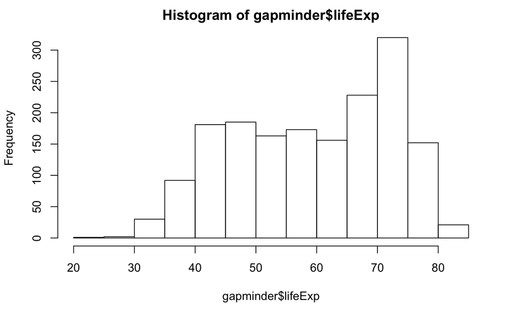

```r
hist(gapminder$lifeExp)
```

This shows a histogram for the values of the lifeExp (continuous) variable.

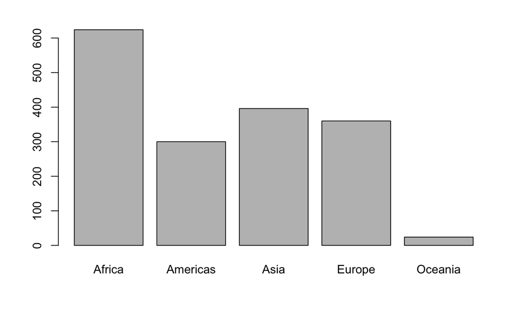

```r
barplot(table(gapminder$continent))
```

This shows a bar plot of the continent (categorical) variable.

**Question:** What is the difference between a bar plot and a histogram?

Soon, we will learn a great deal about data visualization using R.

We end by noting that R is built around **functions**, these are objects that take some number (possibly zero) of input values and return a value. There are many functions built into base R. In addition, there are very many user-developed packages that contain a variety of functions that extend R far beyond its base capabilities. This is what makes R truly powerful. One very interesting package is the swirl package. This package contains functions that allow you to learn R from within R itself. We will look at an example swirl lesson.